# Kümeleme Analizleri ve Uygulamaları

Çoğunluk kuralına göre “ortalama bağlantı (average)” için hiyerarşik kümelemede optimum küme sayısı:

```r
# average bağlantısı
nb.avg <- NbClust(data.scaled, distance = "euclidean", min.nc = 2,max.nc = 10, method = "average", index = "ch")

# sonuçlar görselleştirilir
fviz_nbclust(nb.avg)
```

[output not shown]

```
## Number_clusters     Value_Index
##          2.0000        251.3493
```

```r
# euclidean uzaklık matrisi oluşturulur
dist.mat <- dist(data.scaled, method = "euclidean")

# farklı bağlantılara göre hiyerarşik kümeleme uygulanır
hc.comp<-hclust(dist.mat,method = "complete")
hc.ward<-hclust(dist.mat,method = "ward.D2")
hc.avg<-hclust(dist.mat,method = "average")
```

Complete bağlantısı (k=3):

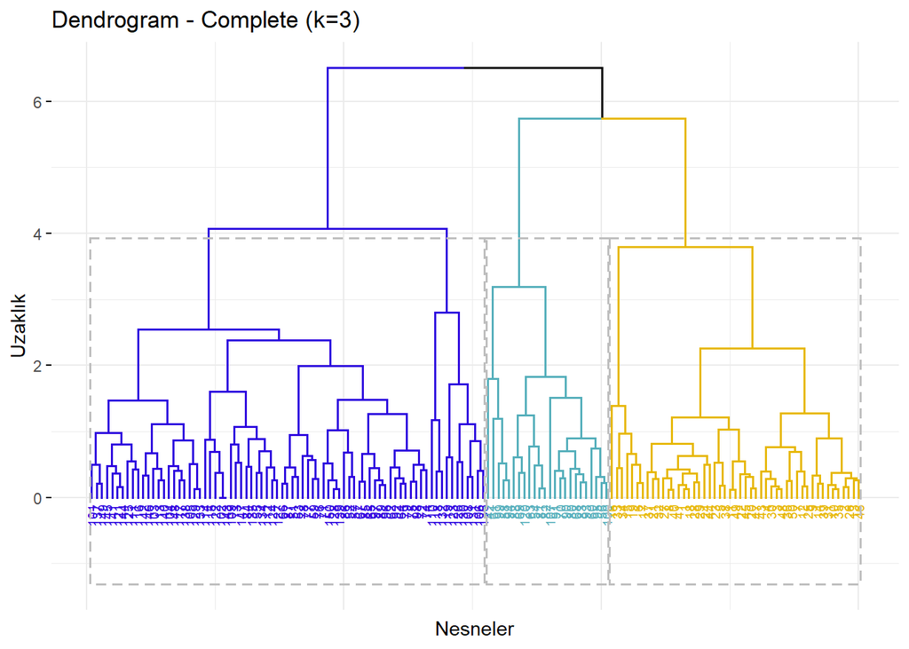

```r
options(ggrepel.max.overlaps = Inf)
# Complete bağlantısı (k=3)
# kümeler 3 grupta toplanır ve farklı kümeler farklı renklerle gösterilir
fviz_dend(hc.comp, k = 3, # Cut in three groups
cex = 0.5, # label size
k_colors = c("#2E00DF", "#55AFBB", "#E7B800"),
color_labels_by_k = TRUE, # color labels by groups
rect = TRUE,
rect_fill=F,main = "Dendrogram - Complete (k=3)",
xlab = "Nesneler", ylab = "Uzaklık", sub = "",
ggtheme = theme_minimal()
)
```

Ward.D2 bağlantısı (k=3):

[figure not shown]

```r
# Ward.D2 bağlantısı (k=3)
# kümeler 3 grupta toplanır ve farklı kümeler farklı renklerle gösterilir
fviz_dend(hc.ward, k = 3,
cex = 0.5, # label size
k_colors = c("#2E00DF", "#55AFBB", "#E7B800"),
color_labels_by_k = TRUE, # color labels by groups
rect = TRUE,
rect_fill=F,main = "Dendrogram - Complete (k=3)",
xlab = "Nesneler", ylab = "Uzaklık", sub = "",
ggtheme = theme_minimal()
)
```

Average bağlantısı (k=3):

[figure not shown]

```r
# Average bağlantısı (k=3)
# kümeler 3 grupta toplanır ve farklı kümeler farklı renklerle gösterilir
fviz_dend(hc.avg, k = 3,
cex = 0.5, # label size
k_colors = c("#2E00DF", "#55AFBB", "#E7B800"),
color_labels_by_k = TRUE,
rect = TRUE,
rect_fill=F,main = "Dendrogram - Complete (k=3)",
xlab = "Nesneler", ylab = "Uzaklık", sub = "",
ggtheme = theme_minimal()
)
```

Average bağlantısı (k=8):

[figure not shown]

```r
# Average bağlantısı (k=8)
#  kümeler 8 grupta toplanır ve farklı kümeler farklı renklerle gösterilir
fviz_dend(hc.avg, k = 8,
cex = 0.5, # label size
k_colors = c("#2E00DF", "#55AFBB", "#E7B800"),
color_labels_by_k = TRUE,
rect = TRUE,
rect_fill=F,main = "Dendrogram - Complete (k=3)",
xlab = "Nesneler", ylab = "Uzaklık", sub = "",
ggtheme = theme_minimal()
)
```

Ortalama tablosu:

```r
# dendoram 3 küme olarak oluşturulur (complete bağlantısı)
grp.comp <- cutree(hc.comp,3)

# kümeler faktöre çevrilir
grp.comp <- as.factor(grp.comp)

# orjinal veri seti kümelere atanır
data.clust.hier <- cbind(data, cluster = grp.comp)

# kümelenmiş verileri kümeye göre toplama
aggregate(data.clust.hier[,1:4], by=list(data.clust.hier$cluster), mean)%>%knitr::kable()
```

| Group.1 | Sepal.Length | Sepal.Width | Petal.Length | Petal.Width |
| --- | --- | --- | --- | --- |
| 1 | 5.016326 | 3.451020 | 1.465306 | 0.244898 |
| 2 | 5.512500 | 2.466667 | 3.866667 | 1.170833 |
| 3 | 6.472727 | 2.990909 | 5.183117 | 1.815584 |

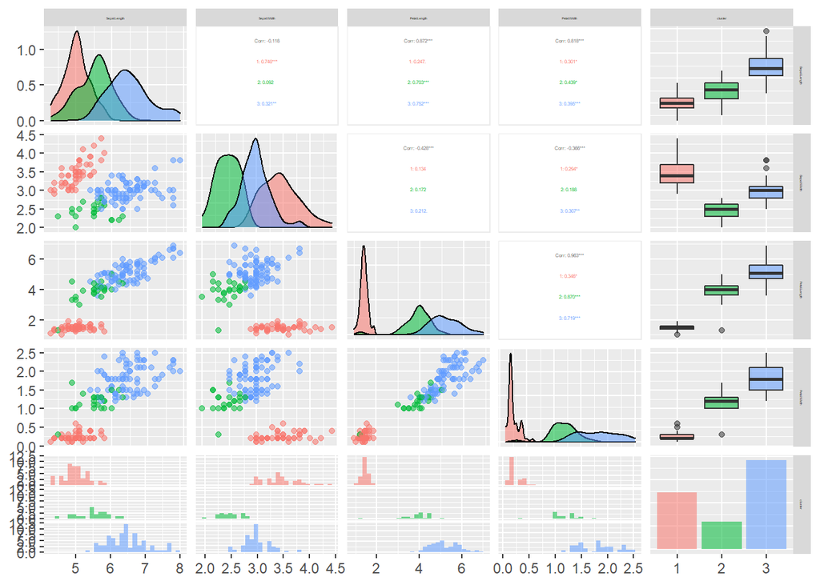

```r
ggpairs(data.clust.hier,aes(color=cluster, alpha=0.5),lower = list(combo = wrap("facethist"))
        ,upper = list(continuous = wrap('cor', size = 1)),binwidth = 0.1) + theme(strip.text = element_text(size = 2))
```

## Küme Sonuçlarını Karşılaştırma

```r
xtabs(~data.clust.kmeans$cluster+data.clust.pam$cluster)
```

```
##                          data.clust.pam$cluster
## data.clust.kmeans$cluster  1  2  3
##                         1 50  0  0
##                         2  0  1 52
##                         3  0 44  3
```

```r
xtabs(~data.clust.kmeans$cluster+data.clust.gmm$cluster)
```

```
##                          data.clust.gmm$cluster
## data.clust.kmeans$cluster  1  2
##                         1 50  0
##                         2  0 53
##                         3  0 47
```

```r
xtabs(~data.clust.kmeans$cluster+data.clust.hier$cluster)
```

```
##                          data.clust.hier$cluster
## data.clust.kmeans$cluster  1  2  3
##                         1 49  1  0
##                         2  0 23 30
##                         3  0  0 47
```

```r
xtabs(~data.clust.pam$cluster+data.clust.gmm$cluster)
```

```
##                       data.clust.gmm$cluster
## data.clust.pam$cluster  1  2
##                      1 50  0
##                      2  0 45
##                      3  0 55
```

```r
xtabs(~data.clust.pam$cluster+data.clust.hier$cluster)
```

```
##                       data.clust.hier$cluster
## data.clust.pam$cluster  1  2  3
##                      1 49  1  0
##                      2  0  0 45
##                      3  0 23 32
```

```r
xtabs(~data.clust.gmm$cluster+data.clust.hier$cluster)
```

```
##                       data.clust.hier$cluster
## data.clust.gmm$cluster  1  2  3
##                      1 49  1  0
##                      2  0 23 77
```

## Model Seçimi

İç geçerlilik ölçümleri: Connectivity, 0 ile sonsuz arasında bir değere sahiptir ve en aza indirilmelidir. Silhouette değeri, belirli bir kümeleme atamasındaki güven derecesini ölçer ve iyi kümelenmiş gözlemlerin 1’e yakın değerlere sahip olduğu ve zayıf kümelenmiş gözlemlerin -1’e yakın değerlere sahip olduğu [-1,1] aralığında yer alır. Dunn İndeksi, aynı kümede olmayan gözlemler arasındaki en küçük mesafenin en büyük küme içi mesafeye oranıdır.

```r
# Model seçimi
suppressPackageStartupMessages( library(clValid))

clmethods <- c("hierarchical","kmeans","pam","model")
intern <- clValid(data.scaled, nClust = 3,clMethods = clmethods, validation = "internal",method="complete")

# Özet
summary(intern)
```

```
##
## Clustering Methods:
##  hierarchical kmeans pam model
##
## Cluster sizes:
##  3
##
## Validation Measures:
##                                  3
##
## hierarchical Connectivity  13.3143
##              Dunn           0.0580
##              Silhouette     0.4496
## kmeans       Connectivity  23.8151
##              Dunn           0.0265
##              Silhouette     0.4599
## pam          Connectivity  23.0726
##              Dunn           0.0571
##              Silhouette     0.4566
## model        Connectivity  24.2524
##              Dunn           0.0739
##              Silhouette     0.3742
##
## Optimal Scores:
##
##              Score   Method       Clusters
## Connectivity 13.3143 hierarchical 3
## Dunn          0.0739 model        3
## Silhouette    0.4599 kmeans       3
```

Stability ölçümleri: Stability ölçüleri, bir kümeleme sonucunun kararlılığını, her seferinde bir sütun kaldırılarak elde edilen kümelerle karşılaştırarak değerlendiren dahili ölçülerin özel bir versiyonudur. Bu ölçüler; the average proportion of non-overlap (APN), the average distance (AD), the average distance between means (ADM), and the figure of merit (FOM) dir. APN, aynı kümeye yerleştirilmeyen gözlemlerin ortalama oranını ölçerken, AD, aynı kümeye yerleştirilen gözlemler arasındaki ortalama mesafeyi ölçer. ADM, aynı kümeye yerleştirilen gözlemler için küme merkezleri arasındaki ortalama mesafeyi ölçer.FOM, kümelemenin kalan (silinmemiş) sütunları temel aldığı, silinen sütunun ortalama küme içi varyansını ölçer.

```r
# Stability ölçümler
clmethods <- c("hierarchical","kmeans","pam","model")

stab <- clValid(data.scaled, nClust = 3, clMethods = clmethods,validation = "stability",method="complete")

# Sadece optimal skorları göster
optimalScores(stab)%>%knitr::kable()
```

|  | Score | Method | Clusters |
| --- | --- | --- | --- |
| APN | 0.1033515 | kmeans | 3 |
| AD | 1.2685400 | kmeans | 3 |
| ADM | 0.2151640 | kmeans | 3 |
| FOM | 0.5032204 | pam | 3 |